# Teste T & ANOVA: Aplicações, gráficos e tabelas

Renata Brandt e Fábio Barros

July 16, 2015

Uma vez que aprendemos a construir/manipular os objetos, abrir arquivos em R (do tipo .xls, .txt, entre outros) e instalar pacotes, podemos pensar em analisar os dados biológicos que foram obtidos durante os experimentos e/ou observações em campo.

A idéia do curso é, gradativamente (em termos da complexidade do modelo), mostrar as análises mais adequadas para determinado tipo de pergunta e como mostrar os resultados graficamente de modo satisfatório para publicação.

## **1. Teste T**

Para iniciarmos, suponhamos que a pergunta do meu projeto esteja relacionado ao efeito da idade sobre a produção de frutos em laranjais.

Neste exemplo, minha hipótese seria a de que indivíduos mais novos produzem proporcionalmente MAIS frutos do que indivíduos mais velhos (medido em kg de frutos/biomassa total de cada árvore).

Durante a tomada dos dados biológicos, eu dividi os indivíduos de determinada área em dois grupos: Grupo “NEW” = Laranjeiras de até 5 anos; Grupo “OLD” = Laranjeiras de mais de 5 anos; foram medido 50 indivíduos de cada grupo.

O teste mais adequado para testar minha hipótese seria um Teste T simples pois eu possuo dois grupos **categorizados** (i.e. Grupo NEW e Grupo OLD). A aplicação do teste “T” de Student é uma função que NÃO requer instalação de novos pacotes, já que está contido no pacote “stats”, dentro de uma série de pacotes já pré-instalados em R.

No sentido de tratarmos somente da análise, eu simulei previamente um conjunto de dados com valores para o **Grupo NEW** e **Grupo OLD** e salvei em .csv.

### *Simulando Dados*

*rnorm* é a função que simula variáveis contínuas normais. A forma de usar é: **x <- rnorm(n, mean, sd)** em que **n** é o tamanho da amostra (x será um vetor caso n > 1), e *mean* e *sd* são parâmetros (opcionais) dando a média e o desvio-padrão da normal. Se *mean* ou *sd* forem omitidos, serão usados os valores, respectivamente, de 0 e 1.

Por exemplo: **x <- rnorm(sd = 2, n = 10)** gera um vetor com 10 valores independentes e identicamente distribuídos, com média zero e desvio-padrão 2.

No caso dos dados biológicos simulados referentes ao exemplo 1:

NEW <- rnorm(50, 200, 45); hist(NEW)

OLD <- rnorm(50, 125, 30); hist(OLD)

orange <- data.frame(cbind(NEW, OLD))

write.csv (orange, “C:/Users/F?bio Barros/Desktop/CursoR/orange.csv”, row.names=F)

### *Validando o Teste T*

Passos:

1. abrir a planilha com os dados:

```r
# definindo o diretório de análise
# cada usuário terá o seu
# setwd("C:/Users/F?bio Barros/Desktop/CursoR")

# para abrir e nomear o conjunto de dados
# laranja<-read.csv('orange.csv')
# Para facilitar, subimos o arquivo na internet e você pode abrir direto do link:
laranja<-read.csv('http://renatabrandt.github.io/EBC2015/data/orange.csv')
```

2. executar a função para Teste T de Student:

```r
t.laranja<-t.test(laranja)
t.laranja
```

```
##
##  One Sample t-test
##
## data:  laranja
## t = 29.02, df = 99, p-value < 2.2e-16
## alternative hypothesis: true mean is not equal to 0
## 95 percent confidence interval:
##  151.2869 173.4932
## sample estimates:
## mean of x
##  162.3901
```

3. visualizar graficamente os resultados:

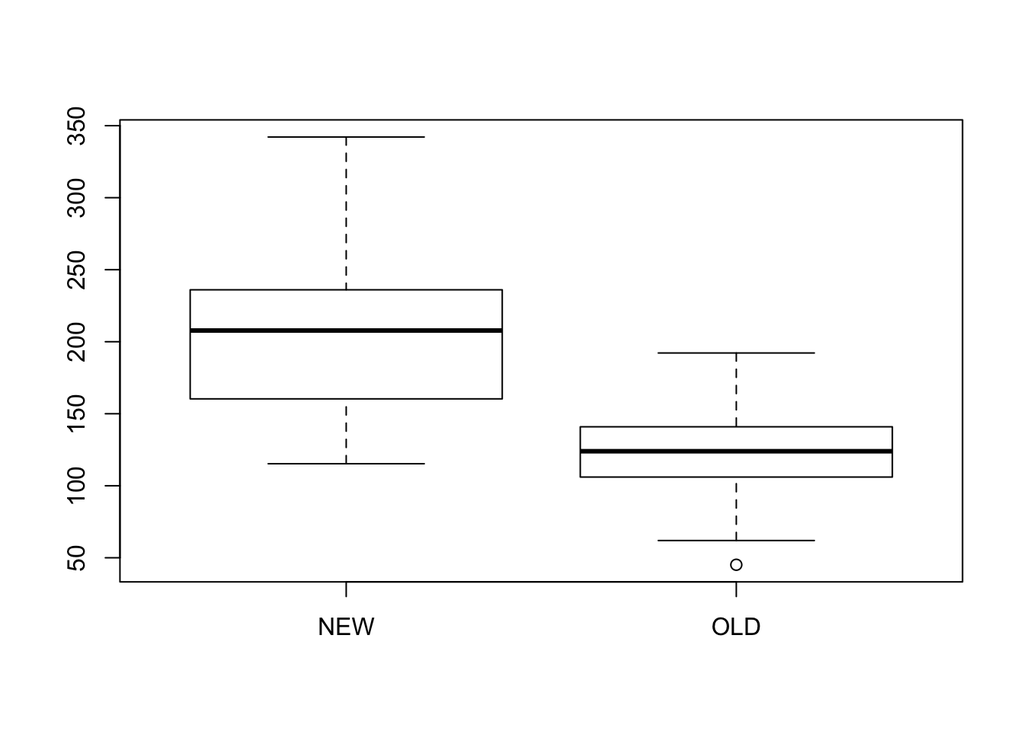

```r
boxplot(laranja)
```

Mas esse gráfico de caixa está meio caidinho hein?! Não está auto-explicativo como uma figura deve ser! Vamos dar um *upgrade* no gráfico? Para isto usaremos a função ggplot, do pacote ggplot2.

### *Criando gráficos*

A vantagem de usar o pacote ggplot2 para produzir gráficos é que a sintaxe é praticamente a mesma em qualquer gráfico que se queria produzir.

Basicamente, para produzir um gráfico em ggplot2, devemos definir qual o conjunto de dados que será utilizado na representação e ainda o tipo de gráfico (se barras, caixa, pontos, entre outros). Depois, pode-se definir os parâmetros secundários.

Lembrando do primeiro bloco, instalaremos o pacote ggplot2, e em seguida produziremos o gráfico que representa a diferença entre os laranjeiras em termos de produção de frutos:

install.packages(“ggplot2”)

```r
require(ggplot2)
```

Para produzir um gráfico no ggplot, devemos reorganizar nosso conjunto de dados de forma que a função consiga “ler” a tabela. Faremos isso usando a função stack():

```r
# função stack reorganiza os dados no data.frame
laranja <- stack(laranja)

# renomeando as colunas
names(laranja) <- c("produto","idade")

# reorganizando as colunas
laranja <- laranja[c("idade", "produto")]
```

E agora vamos de fato produzir o gráfico:

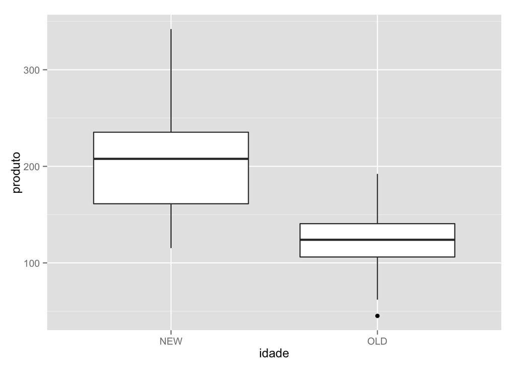

```r
orange.plot <- ggplot(laranja, aes(x=idade, y=produto)) +
                geom_boxplot()
orange.plot
```

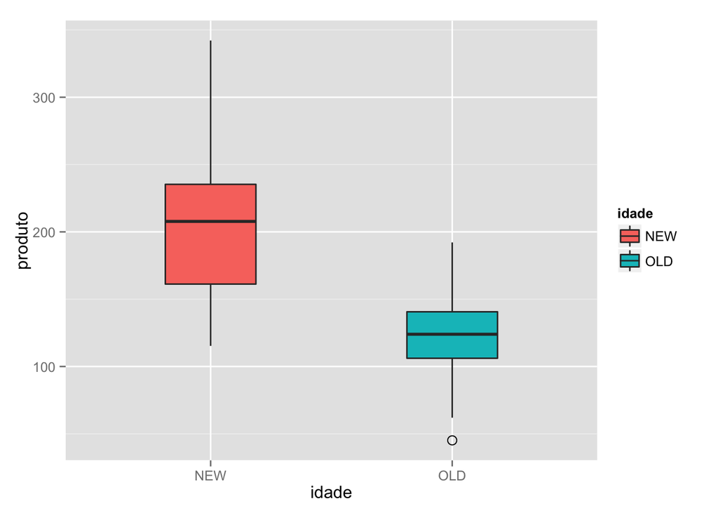

```r
# Podemos melhorar o default gráfico preenchendo cada grupo de
# laranjeiras por cores e mudando a largura do gráfico
orange.plot <- ggplot(laranja, aes(x=idade, y=produto,
                      fill=idade)) +
                geom_boxplot(outlier.size=3,outlier.shape=21, width=0.5)
orange.plot
```

Pronto!!! Temos um gráfico produzino com ggplot2. Para customizá-lo existem muitas opções (muitas mesmo!!!). Como guia básico, nós aconselhamos que os usuários utilizem o [R Graphics Cookbook](http://renatabrandt.gihub.io/EBC2015/artigos/R_Graphics_Cookbook.pdf)

Deixamos esta opção aqui, inclusive com a utilização de fontes alternativas!

install.packages(“extrafont”)

```r
# Para acessar tipos de letras alternativas
# loadfonts(device="win")
require(extrafont)
```

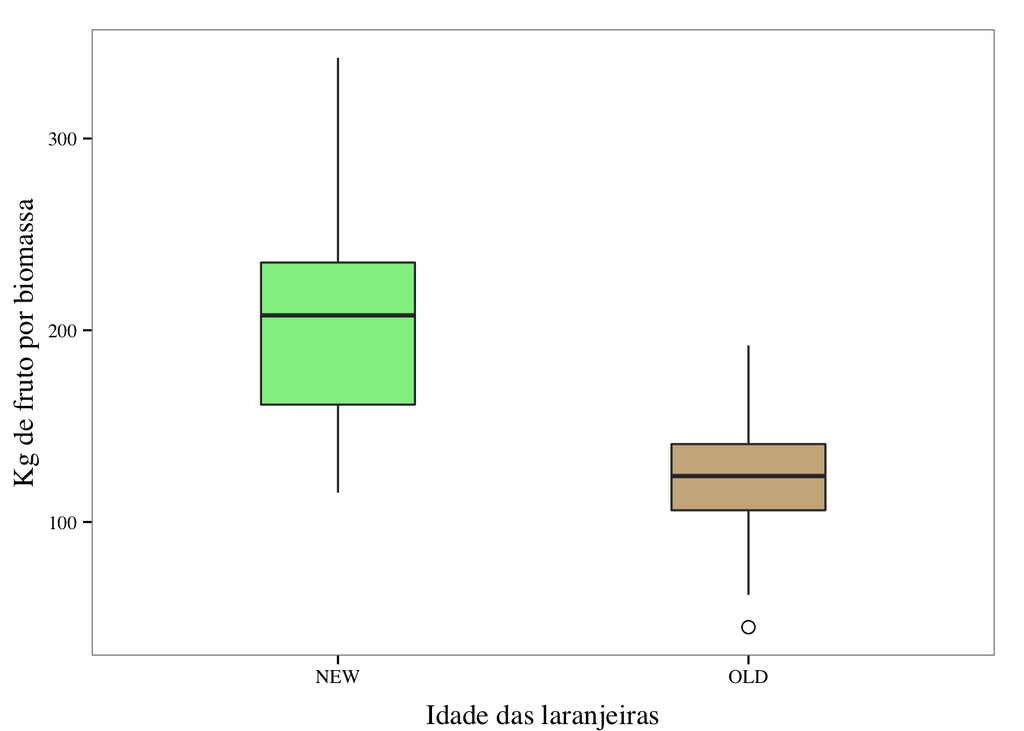

```r
# Aqui definimos um objeto que representa a área de um gráfico em BRANCO.
# Eu incorporei este objeto no gráfico que vem a seguir
# para retirar as linhas de grade
no.grid <- element_blank()


orange.plot.full <- orange.plot +
                    scale_fill_manual(values=c("lightgreen",
                                               "navajowhite3")) +
                    # otimizando cor das variaveis
                    theme_bw(base_size = 12, base_family="Times") +
                    # definindo tamanho e características gerais
                    # da fonte
                    xlab("Idade das laranjeiras") +
                    theme(axis.title.x=element_text(angle=0, size=14)) +
                    theme(axis.title.x=element_text(vjust=-0.50)) +
                    # ajustando Título no eixo X, e distância do
                    # texto em relação ao gráfico
                    ylab("Kg de fruto por biomassa") +
                    theme(axis.title.y=element_text(angle=90, size=14)) +
                    theme(axis.title.y=element_text(vjust=1)) +
                    # o mesmo para o eixo y
                    theme(panel.grid.minor=no.grid,
                          panel.grid.major=no.grid) +
                    # retirando linhas de grade
                    guides(fill=FALSE)
                    # retirando as legendas

orange.plot.full
```

### *Salvando imagens*

O melhor modo de salvar os gráficos para publicação é no formato .pdf ou Postscript (.eps). Estes formatos não alteram a qualidade da figura, mesmo quando aumentadas muitas vezes.

Como fazer? Para gráficos de ggplot2 existe a possibilidade de usar a função ggsave(), que permite customização de formato, tamanho… Para quem usa RStudio, na janela inferior direita clique em “Export -> Save as PDF… -> SAVE”.

## **2. ANOVA**

A ANOVA (*Analysis of Variance*) permite testar se determinados conjuntos de dados possuem médias iguais ou não, levando-se em conta a variação dos números em torno da média. Este método, diferentemente do *Teste T de Student* permite que vários grupos sejam comparados ao mesmo tempo. Em outras palavras, permite testes com um fator que tenha mais de 2 níveis.

Existem muitos pacotes para realizar testes de ANOVA (i.e. ez, car, entre outros), mas a base do R também já contém essa função com uma sintaxe bem simples…

aov(RESPOSTA ~ FATOR), onde assumimos que a variável **RESPOSTA** tem a condição de *dependencia* em relação ao **FATOR**.

Num exemplo hipotético utilizando o conjunto de dados **IRIS** disponível no R, poderíamos fazer desta maneira:

```r
# para carregar o data.frame
iris
```

```
##     Sepal.Length Sepal.Width Petal.Length Petal.Width    Species
## 1            5.1         3.5          1.4         0.2     setosa
## 2            4.9         3.0          1.4         0.2     setosa
## 3            4.7         3.2          1.3         0.2     setosa
## 4            4.6         3.1          1.5         0.2     setosa
## 5            5.0         3.6          1.4         0.2     setosa
## 6            5.4         3.9          1.7         0.4     setosa
## 7            4.6         3.4          1.4         0.3     setosa
## 8            5.0         3.4          1.5         0.2     setosa
## 9            4.4         2.9          1.4         0.2     setosa
## 10           4.9         3.1          1.5         0.1     setosa
## 11           5.4         3.7          1.5         0.2     setosa
## 12           4.8         3.4          1.6         0.2     setosa
## 13           4.8         3.0          1.4         0.1     setosa
## 14           4.3         3.0          1.1         0.1     setosa
```

[output cut: 136 more lines]

```r
# para permitir o acesso direto às colunas do conjunto de dados
attach(iris)

aov.iris <- aov(Petal.Width ~ Species)
summary (aov.iris)
```

```
##              Df Sum Sq Mean Sq F value Pr(>F)
## Species       2  80.41   40.21     960 <2e-16 ***
## Residuals   147   6.16    0.04
## ---
## Signif. codes:  0 '***' 0.001 '**' 0.01 '*' 0.05 '.' 0.1 ' ' 1
```

### *Desafio*

Uma vez que já demonstramos como realizar diversas opera??es no R, propomos aqui nosso primeiro *DESAFIO* do curso:

Vamos pensar novamente na produtividade dos laranjais, que abordamos no item anterior. Digamos que durante observações prévias, percebemos que indivíduos de até 2 anos talvez produzam ainda mais frutos que árvores entre 2 a 5 anos. Neste caso, decidimos por comparar 03 grupos de ?rvores distintas por meio de uma **Análise de Variância**.

1. Simule, por meio da função *rnorm*, 3 vetores referentes aos grupos de laranjeiras teoricamente amostradas pelo pesquisador. O Grupo 1 (de até 2 anos) deve conter 100 amostras, com média 373, e variância de 30; Grupo 2 (de 2 a 5 anos) - 75 amostras, média de 157, e variância de 50; Grupo 3 - 90 amostras, média de 145, e variância de 65.
2. Crie um conjunto de dados (*data.frame*) usando a função *cbind* e *stack*, e altere o nome das colunas usando a função *names*.
3. Aplique o teste de **ANOVA** em seus dados. Em termos dos laranjais, qual é a variável **RESPOSTA**? E qual é o **FATOR** (no caso, a variável independente)? Qual foi o resultado obtido?

### **ANOVA de 2-fatores (*Two-way*) e Interações**

A **ANOVA** realizada anteriormente levou em consideração apenas 1 fator como influente para a produç˜eo de frutos em laranjeiras, no caso, a *idade* dos indivíduos.

Dependendo da pergunta que consideramos responder, podemos observar mais elementos potencialmente influentes na **RESPOSTA**. Por exemplo:

aov(RESPOSTA ~ FatorA + FatorB)

#### *Exemplo prático*

Vamos abrir o arquivo *orange_iii* no qual adicionamos mais um fator ao conjunto de dados. Lembre-se que as variáveis independentes numa **ANOVA** são categóricas e *somente* a variável **RESPOSTA** deve ser contínua.

```r
orange_iii <- read.csv("http://renatabrandt.github.io/EBC2015/data/orange_iii.csv")
str (orange_iii)
```

```
## 'data.frame':    300 obs. of  3 variables:
##  $ age       : Factor w/ 3 levels "interm","old",..: 3 3 3 3 3 3 3 3 3 3 ...
##  $ altitude  : Factor w/ 2 levels "high","low": 2 2 2 2 2 2 2 2 2 2 ...
##  $ production: num  446 435 432 430 429 ...
```

```r
# reparem que o fator "AGE" possui 3 níveis
# enquanto o fator "ALTITUDE" possui 2 níveis
attach (orange_iii)
```

Agora vamos testar o modelo tanto para **Age** quanto para **Altitude**

```r
aov.orange_iii <- aov(production ~ age+altitude)
anova (aov.orange_iii)
```

```
## Analysis of Variance Table
##
## Response: production
##            Df  Sum Sq Mean Sq F value    Pr(>F)
## age         2 3411521 1705761 885.168 < 2.2e-16 ***
## altitude    1   74599   74599  38.711 1.674e-09 ***
## Residuals 296  570406    1927
## ---
## Signif. codes:  0 '***' 0.001 '**' 0.01 '*' 0.05 '.' 0.1 ' ' 1
```

Ainda podemos considerar que existe interação entre os fatores, que refletem alterações nos índices da variável dependente, neste caso:

```r
aov.interaction <- aov(production ~ age + altitude + age:altitude)
anova (aov.interaction)
```

```
## Analysis of Variance Table
##
## Response: production
##               Df  Sum Sq Mean Sq F value    Pr(>F)
## age            2 3411521 1705761 959.819 < 2.2e-16 ***
## altitude       1   74599   74599  41.976 3.882e-10 ***
## age:altitude   2   47918   23959  13.482 2.501e-06 ***
## Residuals    294  522488    1777
## ---
## Signif. codes:  0 '***' 0.001 '**' 0.01 '*' 0.05 '.' 0.1 ' ' 1
```

Como diria Serginho Malandro… Yeah! Yeah! Existe um efeito tanto da *altitude* quanto da *idade* em relação à produção de frutos por laranjeira!

Mas novamente, o teste falha em demonstrar com mais acurácia como os fatores influenciam a produção de frutos e, principalmente, o efeito das interações entre os fatores! Portanto, nós sugerimos que vocês utilizem um pacote mais adequado, por exemplo o *PHIA (Pos-hoc Interaction Analysis)*

### **PHIA (Pos-hoc Interaction Analysis)**

O pacote *phia* é direcionado especificamente para teste de interaões e visualização gráfica. O *default* do pacote é de fácil compreensão e por isso sugerimos que vocês se aprofundem, se tiverem interesse.

Ele funciona com modelos de base **lm**, com sintaxe semelhante aos testes de **ANOVA** que demonstramos anteriormente.

O teste de **ANOVA** num modelo de base **lm** requer a instalação do pacote *car*. Portanto devemos instalá-lo também.

install.packages(“car”)

install.packages(“phia”)

```r
require(car)
require(phia)
```

```r
# O "phia" nos dá opções de fixar um dos fatores
# e somente olhar o efeito no outro fator de interesse

# Ainda podemos plotar as interações, o que é muito interessante!
# Deixamos aqui um exemplo para o conjunto de dados "orange_iii"

phia.orange <- lm(production ~ age*altitude)
Anova(phia.orange, type=3)
```

```
## Anova Table (Type III tests)
##
## Response: production
##               Sum Sq  Df F value    Pr(>F)
## (Intercept)  1188927   1 669.001 < 2.2e-16 ***
## age          2386697   2 671.488 < 2.2e-16 ***
## altitude       95366   1  53.661 2.304e-12 ***
## age:altitude   47918   2  13.482 2.501e-06 ***
## Residuals     522488 294
## ---
## Signif. codes:  0 '***' 0.001 '**' 0.01 '*' 0.05 '.' 0.1 ' ' 1
```

```r
testInteractions(phia.orange, fixed="age",
                 across="altitude", adjustment="bonferroni")
```

```
## F Test:
## P-value adjustment method: bonferroni
##             Value  Df Sum of Sq       F    Pr(>F)
## interm    -64.745   1     95366 53.6615 6.912e-12 ***
##    old     -1.720   1        74  0.0416 1.0000000
##  young    -38.529   1     27077 15.2363 0.0003531 ***
## Residuals         294    522488
## ---
## Signif. codes:  0 '***' 0.001 '**' 0.01 '*' 0.05 '.' 0.1 ' ' 1
```

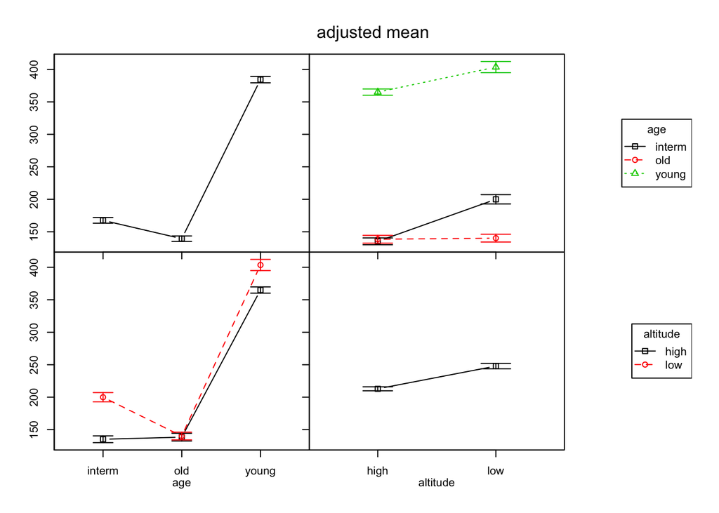

```r
means.orange<-interactionMeans(phia.orange)
plot(means.orange, abbrev.levels=FALSE)
```

E aí? O que acharam? Na nossa opinião as relações ficam muito mais claras de observar utilizando *phia* com poucas linhas de comando.

No exemplo, onde está realmente a diferença? O que ocorre com as laranjeiras mais velhas?